# Data imports and preparation

We begin by importing necessary libraries and loading our gene expression dataset. We already splitted them into train and test.

```python
import numpy as np
import pandas as pd
import matplotlib.pyplot as plt
import seaborn as sns
from scipy.stats import spearmanr
from sklearn.model_selection import train_test_split
from sklearn.metrics import roc_curve, auc
import warnings
warnings.filterwarnings('ignore')
```

```python
X_train = pd.read_csv('train_data.csv', header = 0, index_col=0)
X_test = pd.read_csv('test_data.csv', header = 0, index_col=0)
y_train_initial = pd.read_csv('train_label.csv', index_col=0).iloc[:, 0]
y_test_initial = pd.read_csv('test_label.csv', index_col=0).iloc[:, 0]
```

We transpose the data to have samples as rows and genes as columns, which is the standard format for machine learning applications:

```python
X_train = X_train.T
X_test = X_test.T
```

```python
X_train.head()
```

| Hugo_Symbol | FNDC1 | ENKUR | LOR | JAKMIP1 | TROAP | IL20RB | C12orf23 | MYH10 | ILKAP | RALGPS2 | ... | PITPNM3 | FNIP1 | POLE3 | GCOM1 | MCRS1 | ZNF420 | CCDC115 | SRF | DNAH7 | CHST15 |
| --- | --- | --- | --- | --- | --- | --- | --- | --- | --- | --- | --- | --- | --- | --- | --- | --- | --- | --- | --- | --- | --- |
| DBTRG05MG_CENTRAL_NERVOUS_SYSTEM_ccle_broad_2019 | -1.227233 | -1.111015 | -1.024506 | -1.204982 | 0.429945 | -0.996773 | 1.435845 | 1.086317 | 0.839739 | -0.381627 | ... | -0.959865 | 0.348740 | 1.658128 | -0.831502 | 1.037915 | 0.009348 | 0.887526 | 0.297887 | -1.111097 | -0.252348 |
| GSU_STOMACH_ccle_broad_2019 | -1.184060 | -1.098846 | -0.962687 | -1.123720 | 0.457869 | -0.967586 | 0.621839 | -0.774479 | 0.723629 | 0.014996 | ... | 0.087221 | 0.394980 | 1.634922 | -0.012836 | 1.075512 | -0.360503 | 0.871501 | 0.350929 | -0.937158 | -0.989050 |
| HS888T_FIBROBLAST_ccle_broad_2019 | -1.033267 | -1.185526 | -1.008846 | -1.184397 | 0.488763 | -1.024054 | 1.426750 | 1.394155 | 0.801806 | 0.418507 | ... | -0.539705 | 0.554771 | 1.393498 | -0.883361 | 1.059136 | -0.355687 | 0.921834 | 0.334660 | -1.027697 | -0.646976 |
| RH18_SOFT_TISSUE_ccle_broad_2019 | -0.851226 | -1.173476 | -1.033149 | -1.177620 | 0.010829 | -0.140559 | 1.489846 | 1.260127 | 0.841327 | 0.376593 | ... | -0.977525 | 0.211531 | 1.151020 | -0.923031 | 0.950590 | -0.130618 | 1.148549 | 0.329823 | -1.120003 | 0.400527 |
| LN340_CENTRAL_NERVOUS_SYSTEM_ccle_broad_2019 | -1.265297 | -0.981664 | -1.023899 | -1.196315 | 0.844808 | -0.947690 | 1.426523 | 0.810605 | 1.228653 | -0.207031 | ... | -0.796534 | 0.617996 | 1.877734 | -0.876850 | 1.094495 | -0.186115 | 0.735937 | 0.177677 | -1.045706 | -0.036248 |

5 rows × 13867 columns

```python
X_test.head()
```

| Hugo_Symbol | FNDC1 | ENKUR | LOR | JAKMIP1 | TROAP | IL20RB | C12orf23 | MYH10 | ILKAP | RALGPS2 | ... | PITPNM3 | FNIP1 | POLE3 | GCOM1 | MCRS1 | ZNF420 | CCDC115 | SRF | DNAH7 | CHST15 |
| --- | --- | --- | --- | --- | --- | --- | --- | --- | --- | --- | --- | --- | --- | --- | --- | --- | --- | --- | --- | --- | --- |
| MESSA_SOFT_TISSUE_ccle_broad_2019 | -1.150736 | -1.059105 | -0.976217 | 0.588283 | 0.865650 | -0.790988 | 1.364263 | 1.947542 | 0.687727 | 0.273378 | ... | -1.029573 | 0.311951 | 1.668512 | -0.834795 | 1.227017 | -0.118117 | 0.974760 | 0.137094 | -1.038051 | 0.010005 |
| HEPG2_LIVER_ccle_broad_2019 | -1.128789 | -1.096533 | -0.959369 | -1.109604 | 0.525013 | -1.099945 | 1.355402 | 1.776050 | 1.047374 | 0.334930 | ... | -1.055999 | 0.092377 | 1.525127 | -0.865263 | 1.149162 | -0.177048 | 0.910765 | 0.466082 | -1.038890 | 0.529254 |
| BL41_HAEMATOPOIETIC_AND_LYMPHOID_TISSUE_ccle_broad_2019 | -1.005221 | -1.025056 | -0.880472 | -1.013571 | 1.413927 | -0.784837 | 0.958692 | -0.730858 | 1.385577 | 0.605741 | ... | -1.001275 | -0.045444 | 2.511051 | -0.775517 | 1.485800 | 0.264366 | 1.070482 | 0.481596 | -0.921820 | 0.829244 |
| NCIH69_LUNG_ccle_broad_2019 | -1.310636 | -1.235179 | -1.086196 | -0.240380 | 1.156556 | -0.898968 | 1.347639 | 1.103127 | 1.021540 | -1.126445 | ... | -1.163216 | 0.682159 | 1.908672 | -1.001757 | 1.340603 | 0.249568 | 0.194444 | 0.335196 | -1.021902 | -0.885865 |
| HT1197_URINARY_TRACT_ccle_broad_2019 | -1.124099 | -0.799357 | -0.957225 | -1.106994 | 0.706148 | 1.855022 | 1.156685 | 1.733304 | 0.820043 | 0.809463 | ... | -1.050029 | 0.042360 | 1.826926 | -0.493172 | 1.252135 | -0.410269 | 0.971780 | 0.219673 | -1.032158 | -0.035002 |

5 rows × 13867 columns

```python
y_train_initial
```

```
DBTRG05MG_CENTRAL_NERVOUS_SYSTEM_ccle_broad_2019                   WT
GSU_STOMACH_ccle_broad_2019                                       SNP
HS888T_FIBROBLAST_ccle_broad_2019                                  WT
RH18_SOFT_TISSUE_ccle_broad_2019                                   WT
LN340_CENTRAL_NERVOUS_SYSTEM_ccle_broad_2019                      SNP
                                                                 ...
OV56_OVARY_cellline_ccle_broad                                     WT
JHH6_LIVER_cellline_ccle_broad                                     WT
NCIH929_HAEMATOPOIETIC_AND_LYMPHOID_TISSUE_cellline_ccle_broad     WT
HPAFII_PANCREAS_cellline_ccle_broad                               SNP
647V_URINARY_TRACT_cellline_ccle_broad                            SNP
Name: Variant_Type, Length: 1636, dtype: object
```

```python
y_test_initial
```

```
MESSA_SOFT_TISSUE_ccle_broad_2019                           WT
HEPG2_LIVER_ccle_broad_2019                                 WT
BL41_HAEMATOPOIETIC_AND_LYMPHOID_TISSUE_ccle_broad_2019    SNP
NCIH69_LUNG_ccle_broad_2019                                SNP
HT1197_URINARY_TRACT_ccle_broad_2019                        WT
                                                          ...
OVKATE_OVARY_cellline_ccle_broad                           SNP
NCIH526_LUNG_cellline_ccle_broad                           SNP
S117_SOFT_TISSUE_cellline_ccle_broad                       SNP
ZR7530_BREAST_cellline_ccle_broad                           WT
LU99_LUNG_cellline_ccle_broad                               WT
Name: Variant_Type, Length: 409, dtype: object
```

```python
print(f"Training data shape: {X_train.shape}")
print(f"Training labels distribution: {y_train_initial.value_counts()}")
print()
print(f"Testing data shape: {X_test.shape}")
print(f"Testing labels distribution: {y_test_initial.value_counts()}")
```

```
Training data shape: (1636, 13867)
Training labels distribution: SNP    875
WT     637
DEL     90
INS     25
DNP      9
Name: Variant_Type, dtype: int64

Testing data shape: (409, 13867)
Testing labels distribution: SNP    219
WT     159
DEL     23
INS      6
DNP      2
Name: Variant_Type, dtype: int64
```

Our labels are:

```python
print(y_train_initial.unique())
```

```
['WT' 'SNP' 'INS' 'DEL' 'DNP']
```

- WT (Wild Type): no mutation is present, TP53 is in its normal, unaltered form.
- SNP (Single Nucleotide Polymorphism): a single base pair in the DNA sequence has been changed.
- INS (Insertion): one or more nucleotides have been inserted into the DNA sequence.
- DEL (Deletion): one or more nucleotides have been deleted.
- DNP (Double Nucleotide Polymorphism): two adjacent base pairs have been altered.

After loading the train and test data splits, we convert the original multi-class labels into binary labels for the binary classification task (mutated vs. non-mutated). We do this after splitting to preserve the original multi-class labels (y_train_initial and y_test_initial) for the multi-class classification task we do later on.

We define wild-type ('WT') as class 0 (non-mutated) and all other mutation types as class 1 (mutated).

```python
# Check that X and y are aligned with the same samples in the same order
assert all(X_train.index == y_train_initial.index), "Sample mismatch between features and labels!"
assert all(X_test.index == y_test_initial.index), "Sample mismatch between features and labels!"


y_train = y_train_initial.map(lambda x: 0 if x == 'WT' else 1)
y_test = y_test_initial.map(lambda x: 0 if x == 'WT' else 1)

print(f"Training data shape: {X_train.shape}")
print(f"Training labels distribution: {y_train.value_counts()}")
print()
print(f"Testing data shape: {X_test.shape}")
print(f"Testing labels distribution: {y_test.value_counts()}")
```

```
Training data shape: (1636, 13867)
Training labels distribution: 1    999
0    637
Name: Variant_Type, dtype: int64

Testing data shape: (409, 13867)
Testing labels distribution: 1    250
0    159
Name: Variant_Type, dtype: int64
```

# Selection of target genes

An important part of our analysis is the selection of genes that are connected to the mutated/non-mutated conditions of TP53 to make our prediction.

We identified a list of TP53 target genes—genes whose expression is directly regulated by the TP53 protein. To make predictions, we aim to select a subset of these target genes.

For selection, we rank the target genes based on the absolute value of their Spearman correlation coefficients: for each gene, we calculate the Spearman correlation coefficient with the target variable. Spearman correlation measures the relationship between two variables, providing insight into how changes in one variable are related to changes in another. We only retain genes where the p-value of the correlation is less than or equal to 0.001. This threshold ensures that we focus on genes with statistically significant correlations, reducing the risk of selecting genes with weak or insignificant relationships to the target variable. Finally, we select the top 100 genes with the highest absolute Spearman correlation coefficients. These genes are most strongly associated with the target variable.

Additionally, we explore another approach where we rank all the genes in our dataset according to their Spearman correlation coefficient (not limited to just TP53 target genes) and select a subset of these for classifier construction. We evaluate the performance of both methods to determine which yields the best results.

Our analysis begins by selecting a subset of TP53 target genes with the highest absolute Spearman correlation coefficients.

```python
with open("targets_tp53.txt", "r") as f:
    content = f.read()
    target_genes = [gene.strip().strip('"') for gene in content.split(",") if gene.strip().strip('"') in X_train.T.index]

print(len(target_genes))
```

```
305
```

### TP53 Target Genes Approach

We first filter our dataset to only include known TP53 target genes:

```python
selected_dataset = X_train[target_genes]
selected_dataset.head()
```

| Hugo_Symbol | CDKN1A | ABCA12 | PGPEP1 | RNF19B | EPN3 | SCN4B | ARVCF | FCHO2 | PANK2 | TMEM8B | ... | TP53INP1 | NADSYN1 | PANK1 | RABGGTA | KRT15 | DAPK1 | SCN2A | ARC | FAM98C | TMEM63B |
| --- | --- | --- | --- | --- | --- | --- | --- | --- | --- | --- | --- | --- | --- | --- | --- | --- | --- | --- | --- | --- | --- |
| DBTRG05MG_CENTRAL_NERVOUS_SYSTEM_ccle_broad_2019 | 2.265317 | -1.252340 | 0.391104 | 0.197300 | -0.987781 | -0.826433 | -0.295427 | 0.490774 | 0.927089 | 0.224273 | ... | 0.282661 | 0.461274 | 0.313710 | 0.296290 | -0.706509 | -0.389691 | -1.288269 | -1.160972 | 0.324072 | 0.808109 |
| GSU_STOMACH_ccle_broad_2019 | 2.025846 | -1.254943 | 0.837872 | 0.976773 | 1.023756 | -1.183780 | -0.621598 | 0.742413 | 0.745668 | -0.406261 | ... | 0.291593 | 0.987100 | 0.485633 | 0.672519 | -0.690847 | 0.353272 | -1.238276 | -1.152886 | 0.669106 | 0.915596 |
| HS888T_FIBROBLAST_ccle_broad_2019 | 2.058468 | -1.301592 | 0.442522 | 0.245815 | -1.111713 | 0.170070 | -0.077433 | 0.438734 | 0.743342 | -0.113322 | ... | 0.289818 | 0.419689 | 0.000217 | 0.479382 | -0.811096 | -0.443320 | -0.861088 | -1.042201 | 0.368154 | 0.772971 |
| RH18_SOFT_TISSUE_ccle_broad_2019 | 2.207654 | -1.236383 | 0.575831 | 0.301210 | -1.158607 | -1.245059 | -0.051595 | 0.533383 | 0.984163 | -0.057359 | ... | 0.643091 | 0.444172 | 0.142872 | 0.712808 | -0.578677 | 0.772020 | -1.093942 | -0.829445 | 0.481913 | 0.560997 |
| LN340_CENTRAL_NERVOUS_SYSTEM_ccle_broad_2019 | 0.579822 | -1.270412 | 0.081266 | 0.156340 | -1.052487 | -1.044745 | -0.699176 | 0.251220 | 1.075356 | 0.136656 | ... | -0.318554 | 0.244194 | 0.066337 | 0.091604 | -0.114531 | -0.481132 | -1.232566 | -1.155384 | 0.475469 | 0.627471 |

5 rows × 305 columns

From these target genes, we select the top 100 most significantly correlated with TP53 status using Spearman correlation (p ≤ 0.001):

```python
def select_genes_spearman(dataset):
    correlations = []
    p_values = []
    selected_genes = []
    for column in dataset.columns:
        corr, p_value = spearmanr(dataset[column], y_train)
        if p_value <= 0.001:
            correlations.append(corr)
            p_values.append(p_value)
            selected_genes.append(column)

    corr_results = pd.DataFrame({
        'Gene': selected_genes,
        'Spearman_Correlation': correlations,
        'P_Value': p_values
    })
    corr_results['Abs_Correlation'] = corr_results['Spearman_Correlation'].abs()
    corr_results = corr_results.sort_values(by='Abs_Correlation', ascending=False)

    selected_genes = corr_results.head(100)['Gene'].tolist()
    return selected_genes
```

```python
# selected genes among the target ones
selected_target_genes = select_genes_spearman(selected_dataset)
print(selected_target_genes)
print(len(selected_target_genes))
```

```
['RPS27L', 'CDKN1A', 'MDM2', 'ZMAT3', 'BAX', 'XPC', 'RRM2B', 'DDB2', 'FDXR', 'AEN', 'SESN1', 'PHLDA3', 'ACTA2', 'CCNG1', 'POLH', 'SPATA18', 'TNFRSF10B', 'WDR63', 'DCP1B', 'FAS', 'IKBIP', 'DRAM1', 'ASCC3', 'FBXO22', 'BBC3', 'PPM1D', 'CYFIP2', 'PLK3', 'PHPT1', 'ASTN2', 'ZNF561', 'VWCE', 'TRIM22', 'TP5…
100
```

```python
X_train_target_genes = X_train[selected_target_genes]
```

```python
X_train_target_genes
```

| Hugo_Symbol | RPS27L | CDKN1A | MDM2 | ZMAT3 | BAX | XPC | RRM2B | DDB2 | FDXR | AEN | ... | TNFRSF10A | CROT | SULF2 | PLXNB2 | TRIP6 | PARD6G | CSF1 | MON2 | GPR87 | TSKU |
| --- | --- | --- | --- | --- | --- | --- | --- | --- | --- | --- | --- | --- | --- | --- | --- | --- | --- | --- | --- | --- | --- |
| DBTRG05MG_CENTRAL_NERVOUS_SYSTEM_ccle_broad_2019 | 1.633534 | 2.265317 | 0.546502 | 1.255020 | 1.456598 | 1.036307 | 1.371837 | 1.642948 | 0.847045 | 1.130483 | ... | -0.391559 | 0.591865 | 2.396036 | 1.706232 | 1.414093 | -0.685169 | 0.338438 | 0.390967 | -1.194804 | 0.785269 |
| GSU_STOMACH_ccle_broad_2019 | 1.400989 | 2.025846 | 0.633634 | 0.807556 | 1.410780 | 1.454014 | 0.305858 | 1.382879 | 0.985551 | 1.061674 | ... | 0.863319 | 0.100016 | -1.133415 | 1.501700 | 1.930349 | -1.033581 | -1.185286 | 0.462970 | -1.159598 | 0.795723 |
| HS888T_FIBROBLAST_ccle_broad_2019 | 1.528524 | 2.058468 | 0.349922 | 0.708991 | 1.496255 | 1.113737 | 0.814188 | 1.042515 | 0.411793 | 1.024319 | ... | 0.096270 | 0.421306 | -1.022619 | 1.830803 | 1.731919 | -1.008279 | 0.431866 | 0.511910 | -1.167615 | 0.055891 |
| RH18_SOFT_TISSUE_ccle_broad_2019 | 1.499940 | 2.207654 | 2.294908 | 0.982001 | 1.508338 | 0.815814 | 1.342900 | 1.164317 | 0.665505 | 1.183134 | ... | -0.918450 | 0.693130 | 1.909123 | 1.748879 | 2.013224 | -0.345380 | -0.099945 | 0.469322 | -1.217663 | 0.678513 |
| LN340_CENTRAL_NERVOUS_SYSTEM_ccle_broad_2019 | 0.844300 | 0.579822 | -0.025949 | 0.243565 | 0.938108 | 0.780576 | 0.744061 | 0.629362 | 0.176818 | 0.398728 | ... | -0.864637 | 0.504903 | 1.085315 | 1.413536 | 1.889711 | -0.777355 | 0.761830 | 0.409929 | -1.228849 | 0.693551 |
| ... | ... | ... | ... | ... | ... | ... | ... | ... | ... | ... | ... | ... | ... | ... | ... | ... | ... | ... | ... | ... | ... |
| OV56_OVARY_cellline_ccle_broad | 0.760108 | 0.934962 | -0.046129 | 0.286575 | 0.963654 | 1.019579 | 0.526773 | 0.421204 | -0.279036 | 0.472157 | ... | 0.693464 | -0.401287 | 0.476910 | 1.480382 | 1.125439 | -0.879148 | 0.945593 | 0.542896 | -1.449656 | 0.776257 |
| JHH6_LIVER_cellline_ccle_broad | 1.061755 | 1.379421 | 0.244560 | 0.115597 | 0.931802 | 0.995589 | 1.018513 | 0.952624 | -0.674806 | 0.618564 | ... | 0.682171 | 0.063437 | 0.760937 | 1.361218 | 1.710303 | -0.764437 | -0.493182 | 0.490552 | -1.283083 | 0.828048 |
| NCIH929_HAEMATOPOIETIC_AND_LYMPHOID_TISSUE_cellline_ccle_broad | 1.430158 | 0.943612 | 1.364595 | -0.041348 | 1.273891 | 1.146970 | 0.788238 | 0.997777 | 0.284553 | 1.258407 | ... | 0.936732 | 0.028785 | 1.281718 | 0.757759 | 0.994727 | -0.762392 | -0.466644 | 0.404200 | -1.078727 | -0.023085 |
| HPAFII_PANCREAS_cellline_ccle_broad | 0.642510 | 1.262490 | 0.334763 | -0.010700 | 1.264463 | 0.849087 | 0.198753 | 0.704574 | 0.298059 | 0.587418 | ... | 0.411774 | -0.030100 | 0.806839 | 1.879897 | 1.802607 | -0.922060 | -0.375528 | 0.469242 | 0.636531 | 1.009820 |
| 647V_URINARY_TRACT_cellline_ccle_broad | 1.142293 | 1.231558 | 0.492540 | 0.161386 | 1.268231 | 0.781482 | 0.393424 | 1.120290 | 0.268201 | 0.615742 | ... | 0.745790 | -0.055629 | -1.238183 | 1.676531 | 1.156110 | -0.917579 | -0.630747 | 0.390565 | 0.815650 | 0.581865 |

1636 rows × 100 columns

```python
X_test_target_genes = X_test[selected_target_genes]
```

For comparison, we also apply the Spearman correlation method to all genes to select the top 100 most correlated genes.

```python
# selected genes among all the ones present in the dataset
selected_genes = select_genes_spearman(X_train)
print(selected_genes)
print(len(selected_genes))
```

```
['RPS27L', 'CDKN1A', 'MDM2', 'ZMAT3', 'BAX', 'XPC', 'RRM2B', 'DDB2', 'FDXR', 'AEN', 'SESN1', 'PHLDA3', 'ACTA2', 'CCNG1', 'POLH', 'SPATA18', 'C12orf5', 'TNFRSF10B', 'RPL22L1', 'WDR63', 'DCP1B', 'IFFO1', 'FAS', 'CYGB', 'PKD2', 'RCE1', 'IKBIP', 'DRAM1', 'ASCC3', 'EPCAM', 'CDKN2A', 'DDR2', 'FBXO22', 'CG…
100
```

```python
X_train_subset = X_train[selected_genes]
```

```python
X_test_subset = X_test[selected_genes]
```

# Models

## Binary classifier

Our initial approach is to construct a binary classifier aimed at predicting whether TP53 is mutated or not. The prediction model relies solely on the subset of genes we selected earlier — first using the subset of TP53 target genes and later using the second subset of all genes. We will then compare the performance of these two subsets to evaluate which provides the most accurate predictions.

#### Classifiers implemented:

- Random Forest: effective for high-dimensional data and captures complex interactions
- Logistic Regression: simple baseline model with good interpretability
- Support Vector Machine: works well with high-dimensional data
- K-Nearest Neighbors: might capture local patterns
- XGBoost: powerful gradient boosting method often top-performing
- Neural Network (MLP): can model complex non-linear relationships

Each classifier is implemented with grid search for hyperparameter tuning.

```python
from sklearn.ensemble import RandomForestClassifier
from sklearn.linear_model import LogisticRegression
from sklearn.svm import SVC
from sklearn.neighbors import KNeighborsClassifier
from sklearn.neural_network import MLPClassifier
from xgboost import XGBClassifier
from sklearn.metrics import accuracy_score, precision_score, recall_score, f1_score
from sklearn.metrics import confusion_matrix, roc_curve
from sklearn.model_selection import GridSearchCV
```

```python
# Random Forest

def random_forest(X_train, y_train):
    param_grid_rf = {
        'n_estimators': [50, 100, 200],
        'max_depth': [None, 10, 20, 30],
        'min_samples_split': [2, 5, 10],
        'min_samples_leaf': [1, 2, 4],
        'max_features': ['log2', 'sqrt']
    }

    grid_search_rf = GridSearchCV(
        estimator=RandomForestClassifier(random_state=42),
        param_grid=param_grid_rf,
        cv=5,
        n_jobs=-1,
        verbose=2
    )

    grid_search_rf.fit(X_train, y_train)

    best_params_rf = grid_search_rf.best_params_
    print("Best Random Forest Parameters:", best_params_rf)


    best_rf = grid_search_rf.best_estimator_
    return best_rf
```

```python
# Logistic Regression

def logistic_regression(X_train, y_train):
    param_grid_lr = {
        'C': [0.001, 0.01, 0.1, 1, 10, 100],
        'penalty': ['l1', 'l2'],
        'solver': ['liblinear', 'saga']
    }

    grid_search_lr = GridSearchCV(
        estimator=LogisticRegression(random_state=42, max_iter=1000),
        param_grid=param_grid_lr,
        cv=5,
        n_jobs=-1,
        verbose=2
    )

    grid_search_lr.fit(X_train, y_train)

    best_params_lr = grid_search_lr.best_params_
    print("Best Logistic Regression Parameters:", best_params_lr)

    best_lr = grid_search_lr.best_estimator_
    return best_lr
```

```python
# Support Vector Machine

def svm(X_train, y_train):
    param_grid_svc = {
        'C': [0.1, 1, 10, 100],
        'kernel': ['linear', 'rbf', 'poly'],
        'gamma': ['scale', 'auto', 0.1, 1]
    }

    grid_search_svc = GridSearchCV(
        estimator=SVC(random_state=42),
        param_grid=param_grid_svc,
        cv=5,
        n_jobs=-1,
        verbose=2
    )

    grid_search_svc.fit(X_train, y_train)

    best_params_svc = grid_search_svc.best_params_
    print("Best SVM Parameters:", best_params_svc)

    best_svc = grid_search_svc.best_estimator_
    return best_svc
```

```python
# K-Nearest Neighbors

def knn(X_train, y_train):
    param_grid_knn = {
        'n_neighbors': [3, 5, 7, 9, 11],
        'weights': ['uniform', 'distance'],
        'metric': ['euclidean', 'manhattan', 'minkowski']
    }

    grid_search_knn = GridSearchCV(
        estimator=KNeighborsClassifier(),
        param_grid=param_grid_knn,
        cv=5,
        n_jobs=-1,
        verbose=2
    )

    grid_search_knn.fit(X_train, y_train)

    best_params_knn = grid_search_knn.best_params_
    print("Best KNN Parameters:", best_params_knn)

    best_knn = grid_search_knn.best_estimator_
    return best_knn
```

```python
# XGBoost
def xgboost(X_train, y_train):
    param_grid_xgb_binary = {
        'n_estimators': [100, 200],
        'learning_rate': [0.01, 0.1],
        'max_depth': [3, 5],
        'subsample': [0.8, 1.0],
        'colsample_bytree': [0.8, 1.0]
    }


    xgb = XGBClassifier(
        objective='binary:logistic',
        use_label_encoder=False,
        eval_metric='logloss',
        random_state=42
    )


    grid_search_xgb = GridSearchCV(
        estimator=xgb,
        param_grid=param_grid_xgb_binary,
        cv=5,
        n_jobs=-1,
        verbose=2
    )

    grid_search_xgb.fit(X_train, y_train)

    print("Best XGBoost Parameters:", grid_search_xgb.best_params_)

    best_xgb = grid_search_xgb.best_estimator_
    return best_xgb
```

```python
# Neural Network (MLP)

def neural_netw(X_train, y_train):
    param_grid_nn = {
        'hidden_layer_sizes': [(50,), (100,), (100, 50), (100, 100)],
        'activation': ['relu', 'tanh'],
        'solver': ['adam', 'sgd'],
        'alpha': [0.0001, 0.001, 0.01],
        'learning_rate': ['constant', 'adaptive']
    }

    grid_search_nn = GridSearchCV(
        estimator=MLPClassifier(max_iter=1000, random_state=42),
        param_grid=param_grid_nn,
        cv=5,
        n_jobs=-1,
        verbose=2
    )

    grid_search_nn.fit(X_train, y_train)

    best_params_nn = grid_search_nn.best_params_
    print("Best Neural Network Parameters:", best_params_nn)

    best_nn = grid_search_nn.best_estimator_
    return best_nn
```

Models are evaluated on the test set using accuracy, precision, recall, and F1 score.

```python
best_rf = random_forest(X_train_target_genes, y_train)
y_pred_rf = best_rf.predict(X_test_target_genes)

accuracy_rf = accuracy_score(y_test, y_pred_rf)
precision_rf = precision_score(y_test, y_pred_rf)
recall_rf = recall_score(y_test, y_pred_rf)
f1_rf = f1_score(y_test, y_pred_rf)
```

```
Fitting 5 folds for each of 216 candidates, totalling 1080 fits
Best Random Forest Parameters: {'max_depth': 20, 'max_features': 'sqrt', 'min_samples_leaf': 1, 'min_samples_split': 5, 'n_estimators': 100}
```

```python
best_lr = logistic_regression(X_train_target_genes, y_train)
y_pred_lr = best_lr.predict(X_test_target_genes)

accuracy_lr = accuracy_score(y_test, y_pred_lr)
precision_lr = precision_score(y_test, y_pred_lr)
recall_lr = recall_score(y_test, y_pred_lr)
f1_lr = f1_score(y_test, y_pred_lr)
```

```
Fitting 5 folds for each of 24 candidates, totalling 120 fits
Best Logistic Regression Parameters: {'C': 0.1, 'penalty': 'l1', 'solver': 'liblinear'}
```

```python
best_svc = svm(X_train_target_genes, y_train)
y_pred_svc = best_svc.predict(X_test_target_genes)

accuracy_svc = accuracy_score(y_test, y_pred_svc)
precision_svc = precision_score(y_test, y_pred_svc)
recall_svc = recall_score(y_test, y_pred_svc)
f1_svc = f1_score(y_test, y_pred_svc)
```

```
Fitting 5 folds for each of 48 candidates, totalling 240 fits
Best SVM Parameters: {'C': 1, 'gamma': 'scale', 'kernel': 'poly'}
```

```python
best_knn = knn(X_train_target_genes, y_train)
y_pred_knn = best_knn.predict(X_test_target_genes)

accuracy_knn = accuracy_score(y_test, y_pred_knn)
precision_knn = precision_score(y_test, y_pred_knn)
recall_knn = recall_score(y_test, y_pred_knn)
f1_knn = f1_score(y_test, y_pred_knn)
```

```
Fitting 5 folds for each of 30 candidates, totalling 150 fits
Best KNN Parameters: {'metric': 'manhattan', 'n_neighbors': 7, 'weights': 'distance'}
```

```python
best_xgb = xgboost(X_train_target_genes, y_train)
y_pred_xgb = best_xgb.predict(X_test_target_genes)

accuracy_xgb = accuracy_score(y_test, y_pred_xgb)
precision_xgb = precision_score(y_test, y_pred_xgb)
recall_xgb = recall_score(y_test, y_pred_xgb)
f1_xgb = f1_score(y_test, y_pred_xgb)
```

```
Fitting 5 folds for each of 32 candidates, totalling 160 fits
Best XGBoost Parameters: {'colsample_bytree': 0.8, 'learning_rate': 0.1, 'max_depth': 5, 'n_estimators': 200, 'subsample': 0.8}
```

```python
best_nn = neural_netw(X_train_target_genes, y_train)
y_pred_nn = best_nn.predict(X_test_target_genes)

accuracy_nn = accuracy_score(y_test, y_pred_nn)
precision_nn = precision_score(y_test, y_pred_nn)
recall_nn = recall_score(y_test, y_pred_nn)
f1_nn = f1_score(y_test, y_pred_nn)
```

```
Fitting 5 folds for each of 96 candidates, totalling 480 fits
Best Neural Network Parameters: {'activation': 'tanh', 'alpha': 0.0001, 'hidden_layer_sizes': (50,), 'learning_rate': 'constant', 'solver': 'sgd'}
```

```python
classifiers = [
    ("Random Forest", accuracy_rf, precision_rf, recall_rf, f1_rf),
    ("Logistic Regression", accuracy_lr, precision_lr, recall_lr, f1_lr),
    ("SVM", accuracy_svc, precision_svc, recall_svc, f1_svc),
    ("K-Nearest Neighbors", accuracy_knn, precision_knn, recall_knn, f1_knn),
    ("XGBoost", accuracy_xgb, precision_xgb, recall_xgb, f1_xgb),
    ("Neural Network (MLP)", accuracy_nn, precision_nn, recall_nn, f1_nn)
]

for clf_name, accuracy, precision, recall, f1 in classifiers:
    print(f"{clf_name} Performance:")
    print(f"  Accuracy: {accuracy:.4f} | Precision: {precision:.4f} | Recall: {recall:.4f} | F1 Score: {f1:.4f}\n")
```

```
Random Forest Performance:
  Accuracy: 0.8191 | Precision: 0.8014 | Recall: 0.9360 | F1 Score: 0.8635

Logistic Regression Performance:
  Accuracy: 0.8166 | Precision: 0.7946 | Recall: 0.9440 | F1 Score: 0.8629

SVM Performance:
  Accuracy: 0.8362 | Precision: 0.8144 | Recall: 0.9480 | F1 Score: 0.8762

K-Nearest Neighbors Performance:
  Accuracy: 0.8337 | Precision: 0.8250 | Recall: 0.9240 | F1 Score: 0.8717

XGBoost Performance:
  Accuracy: 0.8289 | Precision: 0.8169 | Recall: 0.9280 | F1 Score: 0.8689

Neural Network (MLP) Performance:
  Accuracy: 0.8264 | Precision: 0.8231 | Recall: 0.9120 | F1 Score: 0.8653
```

We plot the confusion matrices.  
A confusion matrix is a table that summarizes the performance of a classification model by comparing actual and predicted labels. It shows the counts of True Positives (correctly predicted positives), False Positives (incorrectly predicted positives), True Negatives (correctly predicted negatives), False Negatives (incorrectly predicted negatives).

```python
cm_rf = confusion_matrix(y_test, y_pred_rf)
cm_lr = confusion_matrix(y_test, y_pred_lr)
cm_svc = confusion_matrix(y_test, y_pred_svc)
cm_knn = confusion_matrix(y_test, y_pred_knn)
cm_xgb = confusion_matrix(y_test, y_pred_xgb)
cm_nn = confusion_matrix(y_test, y_pred_nn)
```

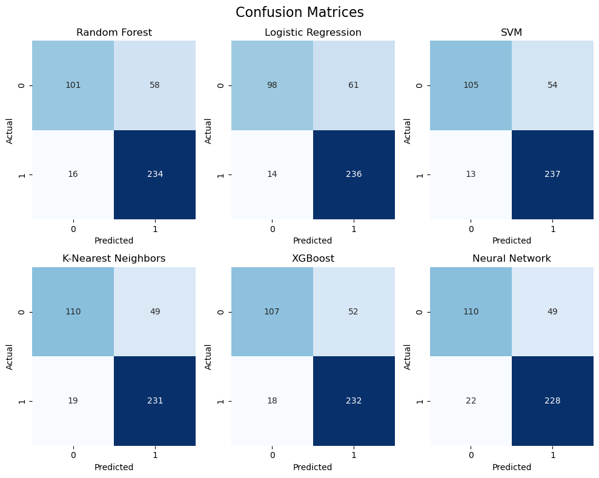

```python
classifier_names = [
    'Random Forest', 'Logistic Regression', 'SVM',
    'K-Nearest Neighbors', 'XGBoost', 'Neural Network'
]

fig, axes = plt.subplots(2, 3, figsize=(10, 8))
fig.suptitle('Confusion Matrices', fontsize=16)

axes = axes.ravel()


for i, (cm, name) in enumerate(zip(
    [cm_rf, cm_lr, cm_svc, cm_knn, cm_xgb, cm_nn],
    classifier_names
)):
    sns.heatmap(cm, annot=True, fmt='d', cmap='Blues', ax=axes[i], cbar=False)
    axes[i].set_title(name)
    axes[i].set_xlabel('Predicted')
    axes[i].set_ylabel('Actual')

plt.tight_layout()
plt.show()
```

Overall the best F1 score is achieved by SVM with parameters {'C': 1, 'gamma': 'scale', 'kernel': 'poly'}.

We now assess the performance of the same classifiers, but this time trained on a dataset that includes a subset of genes with the highest absolute Spearman correlations, without limiting the selection to target genes.

```python
best_rf = random_forest(X_train_subset, y_train)
y_pred_rf = best_rf.predict(X_test_subset)

accuracy_rf = accuracy_score(y_test, y_pred_rf)
precision_rf = precision_score(y_test, y_pred_rf)
recall_rf = recall_score(y_test, y_pred_rf)
f1_rf = f1_score(y_test, y_pred_rf)
```

```
Fitting 5 folds for each of 216 candidates, totalling 1080 fits
Best Random Forest Parameters: {'max_depth': 20, 'max_features': 'sqrt', 'min_samples_leaf': 1, 'min_samples_split': 5, 'n_estimators': 200}
```

```python
best_lr = logistic_regression(X_train_subset, y_train)
y_pred_lr = best_lr.predict(X_test_subset)

accuracy_lr = accuracy_score(y_test, y_pred_lr)
precision_lr = precision_score(y_test, y_pred_lr)
recall_lr = recall_score(y_test, y_pred_lr)
f1_lr = f1_score(y_test, y_pred_lr)
```

```
Fitting 5 folds for each of 24 candidates, totalling 120 fits
Best Logistic Regression Parameters: {'C': 0.1, 'penalty': 'l2', 'solver': 'saga'}
```

```python
best_svc = svm(X_train_subset, y_train)
y_pred_svc = best_svc.predict(X_test_subset)

accuracy_svc = accuracy_score(y_test, y_pred_svc)
precision_svc = precision_score(y_test, y_pred_svc)
recall_svc = recall_score(y_test, y_pred_svc)
f1_svc = f1_score(y_test, y_pred_svc)
```

```
Fitting 5 folds for each of 48 candidates, totalling 240 fits
Best SVM Parameters: {'C': 10, 'gamma': 'auto', 'kernel': 'poly'}
```

```python
best_knn = knn(X_train_subset, y_train)
y_pred_knn = best_knn.predict(X_test_subset)

accuracy_knn = accuracy_score(y_test, y_pred_knn)
precision_knn = precision_score(y_test, y_pred_knn)
recall_knn = recall_score(y_test, y_pred_knn)
f1_knn = f1_score(y_test, y_pred_knn)
```

```
Fitting 5 folds for each of 30 candidates, totalling 150 fits
Best KNN Parameters: {'metric': 'manhattan', 'n_neighbors': 11, 'weights': 'distance'}
```

```python
best_xgb = xgboost(X_train_subset, y_train)
y_pred_xgb = best_xgb.predict(X_test_subset)

accuracy_xgb = accuracy_score(y_test, y_pred_xgb)
precision_xgb = precision_score(y_test, y_pred_xgb)
recall_xgb = recall_score(y_test, y_pred_xgb)
f1_xgb = f1_score(y_test, y_pred_xgb)
```

```
Fitting 5 folds for each of 32 candidates, totalling 160 fits
Best XGBoost Parameters: {'colsample_bytree': 1.0, 'learning_rate': 0.1, 'max_depth': 5, 'n_estimators': 200, 'subsample': 1.0}
```

```python
best_nn = neural_netw(X_train_subset, y_train)
y_pred_nn = best_nn.predict(X_test_subset)

accuracy_nn = accuracy_score(y_test, y_pred_nn)
precision_nn = precision_score(y_test, y_pred_nn)
recall_nn = recall_score(y_test, y_pred_nn)
f1_nn = f1_score(y_test, y_pred_nn)
```

```
Fitting 5 folds for each of 96 candidates, totalling 480 fits
Best Neural Network Parameters: {'activation': 'relu', 'alpha': 0.0001, 'hidden_layer_sizes': (100,), 'learning_rate': 'constant', 'solver': 'sgd'}
```

```python
classifiers = [
    ("Random Forest", accuracy_rf, precision_rf, recall_rf, f1_rf),
    ("Logistic Regression", accuracy_lr, precision_lr, recall_lr, f1_lr),
    ("SVM", accuracy_svc, precision_svc, recall_svc, f1_svc),
    ("K-Nearest Neighbors", accuracy_knn, precision_knn, recall_knn, f1_knn),
    ("XGBoost", accuracy_xgb, precision_xgb, recall_xgb, f1_xgb),
    ("Neural Network (MLP)", accuracy_nn, precision_nn, recall_nn, f1_nn)
]

for clf_name, accuracy, precision, recall, f1 in classifiers:
    print(f"{clf_name} Performance:")
    print(f"  Accuracy: {accuracy:.4f} | Precision: {precision:.4f} | Recall: {recall:.4f} | F1 Score: {f1:.4f}\n")
```

```
Random Forest Performance:
  Accuracy: 0.8289 | Precision: 0.8082 | Recall: 0.9440 | F1 Score: 0.8708

Logistic Regression Performance:
  Accuracy: 0.8068 | Precision: 0.7979 | Recall: 0.9160 | F1 Score: 0.8529

SVM Performance:
  Accuracy: 0.8313 | Precision: 0.8198 | Recall: 0.9280 | F1 Score: 0.8705

K-Nearest Neighbors Performance:
  Accuracy: 0.8215 | Precision: 0.8020 | Recall: 0.9400 | F1 Score: 0.8656

XGBoost Performance:
  Accuracy: 0.8215 | Precision: 0.8218 | Recall: 0.9040 | F1 Score: 0.8610

Neural Network (MLP) Performance:
  Accuracy: 0.8044 | Precision: 0.8036 | Recall: 0.9000 | F1 Score: 0.8491
```

```python
cm_rf = confusion_matrix(y_test, y_pred_rf)
cm_lr = confusion_matrix(y_test, y_pred_lr)
cm_svc = confusion_matrix(y_test, y_pred_svc)
cm_knn = confusion_matrix(y_test, y_pred_knn)
cm_xgb = confusion_matrix(y_test, y_pred_xgb)
cm_nn = confusion_matrix(y_test, y_pred_nn)
```

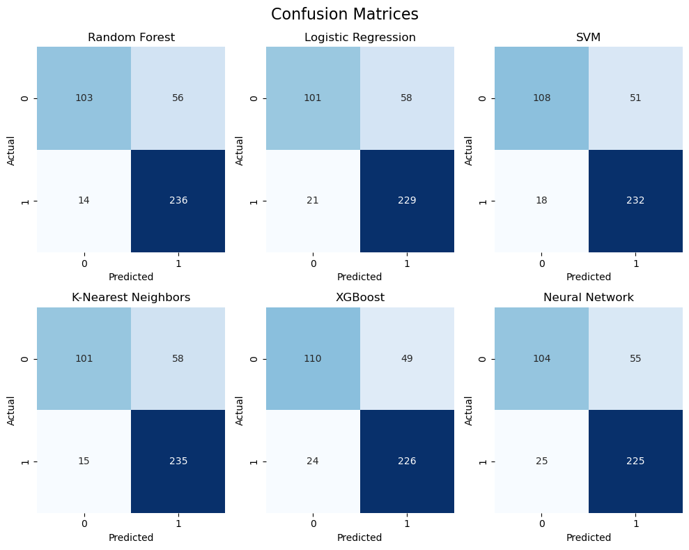

```python
classifier_names = [
    'Random Forest', 'Logistic Regression', 'SVM',
    'K-Nearest Neighbors', 'XGBoost', 'Neural Network'
]

fig, axes = plt.subplots(2, 3, figsize=(10, 8))
fig.suptitle('Confusion Matrices', fontsize=16)

axes = axes.ravel()

for i, (cm, name) in enumerate(zip(
    [cm_rf, cm_lr, cm_svc, cm_knn, cm_xgb, cm_nn],
    classifier_names
)):
    sns.heatmap(cm, annot=True, fmt='d', cmap='Blues', ax=axes[i], cbar=False)
    axes[i].set_title(name)
    axes[i].set_xlabel('Predicted')
    axes[i].set_ylabel('Actual')

plt.tight_layout()
plt.show()
```

The performance of the models trained on the top 100 genes—selected based on absolute Spearman correlation without restricting to TP53 target genes—is comparable to that of models trained solely on the TP53 target gene subset. This indicates that the subset of selected target genes is informative and effective for addressing the binary classification task.

The highest overall F1 score is obtained using an SVM model trained on the TP53 target gene subset with optimized hyperparameters:  
{'C': 1, 'gamma': 'scale', 'kernel': 'poly'}  
Performance: Accuracy: 0.8362 | Precision: 0.8144 | Recall: 0.9480 | F1 Score: 0.8762

## Multi-class classifier

We repeat the same procedure, trying now to predict the specific mutation of TP53.

We use the same subsets of genes selected before to make our predictions.

```python
y_train = y_train_initial
y_test = y_test_initial
```

```python
print(f"Training data shape: {X_train.shape}")
print(f"Training labels distribution:\n{y_train.value_counts()}")
print()
print(f"Testing data shape: {X_test.shape}")
print(f"Testing labels distribution:\n{y_test.value_counts()}")
```

```
Training data shape: (1636, 13867)
Training labels distribution:
SNP    875
WT     637
DEL     90
INS     25
DNP      9
Name: Variant_Type, dtype: int64

Testing data shape: (409, 13867)
Testing labels distribution:
SNP    219
WT     159
DEL     23
INS      6
DNP      2
Name: Variant_Type, dtype: int64
```

The number of samples with the 'DNP' mutation is very small, so we remove them to prevent their disproportionate influence on the classification model, which could negatively impact performance.

```python
train_mask = y_train != 'DNP'
X_train_target_genes = X_train_target_genes[train_mask]
X_train_subset = X_train_subset[train_mask]
y_train = y_train[train_mask]

test_mask = y_test != 'DNP'
X_test_target_genes = X_test_target_genes[test_mask]
X_test_subset = X_test_subset[test_mask]
y_test = y_test[test_mask]
```

```python
print(f"Training data shape: {X_train.shape}")
print(f"Training labels distribution:\n{y_train.value_counts()}")
print()
print(f"Testing data shape: {X_test.shape}")
print(f"Testing labels distribution:\n{y_test.value_counts()}")
```

```
Training data shape: (1636, 13867)
Training labels distribution:
SNP    875
WT     637
DEL     90
INS     25
Name: Variant_Type, dtype: int64

Testing data shape: (409, 13867)
Testing labels distribution:
SNP    219
WT     159
DEL     23
INS      6
Name: Variant_Type, dtype: int64
```

In this multi-class classification task, the dataset is imbalanced, with some TP53 mutation types being much more common than others. To evaluate model performance fairly, we use average='weighted' for metrics like precision, recall, and F1 score.

This approach calculates the metric for each class and then averages them, weighted by the number of true instances per class. This ensures that more frequent classes have a greater impact on the final score, while still including performance on rare classes.

As before, we begin with the dataset using the subset of target genes as features.

```python
best_rf = random_forest(X_train_target_genes, y_train)
y_pred_rf = best_rf.predict(X_test_target_genes)

accuracy_rf = accuracy_score(y_test, y_pred_rf)
precision_rf = precision_score(y_test, y_pred_rf, average='weighted')
recall_rf = recall_score(y_test, y_pred_rf, average='weighted')
f1_rf = f1_score(y_test, y_pred_rf, average='weighted')
```

```
Fitting 5 folds for each of 216 candidates, totalling 1080 fits
Best Random Forest Parameters: {'max_depth': 20, 'max_features': 'sqrt', 'min_samples_leaf': 2, 'min_samples_split': 5, 'n_estimators': 200}
```

```python
best_lr = logistic_regression(X_train_target_genes, y_train)
y_pred_lr = best_lr.predict(X_test_target_genes)

accuracy_lr = accuracy_score(y_test, y_pred_lr)
precision_lr = precision_score(y_test, y_pred_lr, average='weighted')
recall_lr = recall_score(y_test, y_pred_lr, average='weighted')
f1_lr = f1_score(y_test, y_pred_lr, average='weighted')
```

```
Fitting 5 folds for each of 24 candidates, totalling 120 fits
Best Logistic Regression Parameters: {'C': 0.01, 'penalty': 'l2', 'solver': 'liblinear'}
```

```python
best_svc = svm(X_train_target_genes, y_train)
y_pred_svc = best_svc.predict(X_test_target_genes)

accuracy_svc = accuracy_score(y_test, y_pred_svc)
precision_svc = precision_score(y_test, y_pred_svc, average='weighted')
recall_svc = recall_score(y_test, y_pred_svc, average='weighted')
f1_svc = f1_score(y_test, y_pred_svc, average='weighted')
```

```
Fitting 5 folds for each of 48 candidates, totalling 240 fits
Best SVM Parameters: {'C': 10, 'gamma': 0.1, 'kernel': 'rbf'}
```

```python
best_knn = knn(X_train_target_genes, y_train)
y_pred_knn = best_knn.predict(X_test_target_genes)

accuracy_knn = accuracy_score(y_test, y_pred_knn)
precision_knn = precision_score(y_test, y_pred_knn, average='weighted')
recall_knn = recall_score(y_test, y_pred_knn, average='weighted')
f1_knn = f1_score(y_test, y_pred_knn, average='weighted')
```

```
Fitting 5 folds for each of 30 candidates, totalling 150 fits
Best KNN Parameters: {'metric': 'manhattan', 'n_neighbors': 3, 'weights': 'distance'}
```

```python
from sklearn.preprocessing import LabelEncoder

# XGBoost is expecting numerical labels --> need to convert labels
le = LabelEncoder()
y_train_encoded = le.fit_transform(y_train)
y_test_encoded = le.transform(y_test)


best_xgb = xgboost(X_train_target_genes, y_train_encoded)
y_pred_xgb = best_xgb.predict(X_test_target_genes)

accuracy_xgb = accuracy_score(y_test_encoded, y_pred_xgb)
precision_xgb = precision_score(y_test_encoded, y_pred_xgb, average='weighted')
recall_xgb = recall_score(y_test_encoded, y_pred_xgb, average='weighted')
f1_xgb = f1_score(y_test_encoded, y_pred_xgb, average='weighted')
```

```
Fitting 5 folds for each of 32 candidates, totalling 160 fits
Best XGBoost Parameters: {'colsample_bytree': 1.0, 'learning_rate': 0.1, 'max_depth': 5, 'n_estimators': 200, 'subsample': 1.0}
```

```python
best_nn = neural_netw(X_train_target_genes, y_train)
y_pred_nn = best_nn.predict(X_test_target_genes)

accuracy_nn = accuracy_score(y_test, y_pred_nn)
precision_nn = precision_score(y_test, y_pred_nn, average='weighted')
recall_nn = recall_score(y_test, y_pred_nn, average='weighted')
f1_nn = f1_score(y_test, y_pred_nn, average='weighted')
```

```
Fitting 5 folds for each of 96 candidates, totalling 480 fits
Best Neural Network Parameters: {'activation': 'relu', 'alpha': 0.01, 'hidden_layer_sizes': (100, 50), 'learning_rate': 'constant', 'solver': 'adam'}
```

```python
classifiers = [
    ("Random Forest", accuracy_rf, precision_rf, recall_rf, f1_rf),
    ("Logistic Regression", accuracy_lr, precision_lr, recall_lr, f1_lr),
    ("SVM", accuracy_svc, precision_svc, recall_svc, f1_svc),
    ("K-Nearest Neighbors", accuracy_knn, precision_knn, recall_knn, f1_knn),
    ("XGBoost", accuracy_xgb, precision_xgb, recall_xgb, f1_xgb),
    ("Neural Network (MLP)", accuracy_nn, precision_nn, recall_nn, f1_nn)
]

for clf_name, accuracy, precision, recall, f1 in classifiers:
    print(f"{clf_name} Performance:")
    print(f"  Accuracy: {accuracy:.4f} | Precision: {precision:.4f} | Recall: {recall:.4f} | F1 Score: {f1:.4f}\n")
```

```
Random Forest Performance:
  Accuracy: 0.7568 | Precision: 0.7246 | Recall: 0.7568 | F1 Score: 0.7239

Logistic Regression Performance:
  Accuracy: 0.7518 | Precision: 0.7160 | Recall: 0.7518 | F1 Score: 0.7197

SVM Performance:
  Accuracy: 0.8010 | Precision: 0.7998 | Recall: 0.8010 | F1 Score: 0.7915

K-Nearest Neighbors Performance:
  Accuracy: 0.7789 | Precision: 0.7720 | Recall: 0.7789 | F1 Score: 0.7736

XGBoost Performance:
  Accuracy: 0.7494 | Precision: 0.7073 | Recall: 0.7494 | F1 Score: 0.7182

Neural Network (MLP) Performance:
  Accuracy: 0.7592 | Precision: 0.7522 | Recall: 0.7592 | F1 Score: 0.7459
```

```python
cm_rf = confusion_matrix(y_test, y_pred_rf)
cm_lr = confusion_matrix(y_test, y_pred_lr)
cm_svc = confusion_matrix(y_test, y_pred_svc)
cm_knn = confusion_matrix(y_test, y_pred_knn)
cm_xgb = confusion_matrix(y_test_encoded, y_pred_xgb)
cm_nn = confusion_matrix(y_test, y_pred_nn)
```

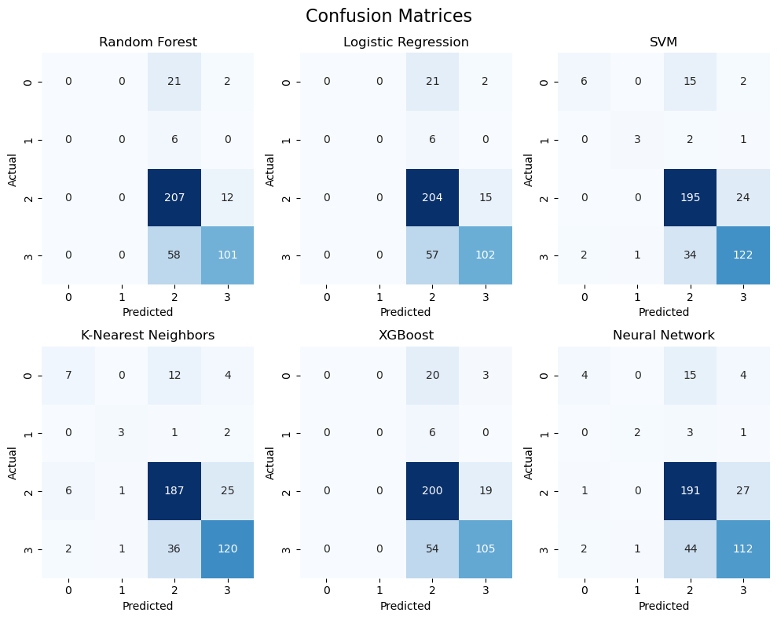

```python
classifier_names = [
    'Random Forest', 'Logistic Regression', 'SVM',
    'K-Nearest Neighbors', 'XGBoost', 'Neural Network'
]

fig, axes = plt.subplots(2, 3, figsize=(10, 8))
fig.suptitle('Confusion Matrices', fontsize=16)

axes = axes.ravel()


for i, (cm, name) in enumerate(zip(
    [cm_rf, cm_lr, cm_svc, cm_knn, cm_xgb, cm_nn],
    classifier_names
)):
    sns.heatmap(cm, annot=True, fmt='d', cmap='Blues', ax=axes[i], cbar=False)
    axes[i].set_title(name)
    axes[i].set_xlabel('Predicted')
    axes[i].set_ylabel('Actual')

plt.tight_layout()
plt.show()
```

Overall the best F1 score is achieved by SVM with parameters {'C': 10, 'gamma': 0.1, 'kernel': 'rbf'}.

Next, we evaluate performance using the dataset that uses the full gene subset as features.

```python
best_rf = random_forest(X_train_subset, y_train)
y_pred_rf = best_rf.predict(X_test_subset)

accuracy_rf = accuracy_score(y_test, y_pred_rf)
precision_rf = precision_score(y_test, y_pred_rf, average='weighted')
recall_rf = recall_score(y_test, y_pred_rf, average='weighted')
f1_rf = f1_score(y_test, y_pred_rf, average='weighted')
```

```
Fitting 5 folds for each of 216 candidates, totalling 1080 fits
Best Random Forest Parameters: {'max_depth': None, 'max_features': 'sqrt', 'min_samples_leaf': 1, 'min_samples_split': 2, 'n_estimators': 200}
```

```python
best_lr = logistic_regression(X_train_subset, y_train)
y_pred_lr = best_lr.predict(X_test_subset)

accuracy_lr = accuracy_score(y_test, y_pred_lr)
precision_lr = precision_score(y_test, y_pred_lr, average='weighted')
recall_lr = recall_score(y_test, y_pred_lr, average='weighted')
f1_lr = f1_score(y_test, y_pred_lr, average='weighted')
```

```
Fitting 5 folds for each of 24 candidates, totalling 120 fits
Best Logistic Regression Parameters: {'C': 0.01, 'penalty': 'l2', 'solver': 'saga'}
```

```python
best_svc = svm(X_train_subset, y_train)
y_pred_svc = best_svc.predict(X_test_subset)

accuracy_svc = accuracy_score(y_test, y_pred_svc)
precision_svc = precision_score(y_test, y_pred_svc, average='weighted')
recall_svc = recall_score(y_test, y_pred_svc, average='weighted')
f1_svc = f1_score(y_test, y_pred_svc, average='weighted')
```

```
Fitting 5 folds for each of 48 candidates, totalling 240 fits
Best SVM Parameters: {'C': 10, 'gamma': 0.1, 'kernel': 'rbf'}
```

```python
best_knn = knn(X_train_subset, y_train)
y_pred_knn = best_knn.predict(X_test_subset)

accuracy_knn = accuracy_score(y_test, y_pred_knn)
precision_knn = precision_score(y_test, y_pred_knn, average='weighted')
recall_knn = recall_score(y_test, y_pred_knn, average='weighted')
f1_knn = f1_score(y_test, y_pred_knn, average='weighted')
```

```
Fitting 5 folds for each of 30 candidates, totalling 150 fits
Best KNN Parameters: {'metric': 'manhattan', 'n_neighbors': 7, 'weights': 'distance'}
```

```python
best_xgb = xgboost(X_train_subset, y_train_encoded)
y_pred_xgb = best_xgb.predict(X_test_subset)

accuracy_xgb = accuracy_score(y_test_encoded, y_pred_xgb)
precision_xgb = precision_score(y_test_encoded, y_pred_xgb, average='weighted')
recall_xgb = recall_score(y_test_encoded, y_pred_xgb, average='weighted')
f1_xgb = f1_score(y_test_encoded, y_pred_xgb, average='weighted')
```

```
Fitting 5 folds for each of 32 candidates, totalling 160 fits
Best XGBoost Parameters: {'colsample_bytree': 1.0, 'learning_rate': 0.1, 'max_depth': 5, 'n_estimators': 100, 'subsample': 1.0}
```

```python
best_nn = neural_netw(X_train_subset, y_train)
y_pred_nn = best_nn.predict(X_test_subset)

accuracy_nn = accuracy_score(y_test, y_pred_nn)
precision_nn = precision_score(y_test, y_pred_nn, average='weighted')
recall_nn = recall_score(y_test, y_pred_nn, average='weighted')
f1_nn = f1_score(y_test, y_pred_nn, average='weighted')
```

```
Fitting 5 folds for each of 96 candidates, totalling 480 fits
Best Neural Network Parameters: {'activation': 'tanh', 'alpha': 0.01, 'hidden_layer_sizes': (100,), 'learning_rate': 'constant', 'solver': 'adam'}
```

```python
classifiers = [
    ("Random Forest", accuracy_rf, precision_rf, recall_rf, f1_rf),
    ("Logistic Regression", accuracy_lr, precision_lr, recall_lr, f1_lr),
    ("SVM", accuracy_svc, precision_svc, recall_svc, f1_svc),
    ("K-Nearest Neighbors", accuracy_knn, precision_knn, recall_knn, f1_knn),
    ("XGBoost", accuracy_xgb, precision_xgb, recall_xgb, f1_xgb),
    ("Neural Network (MLP)", accuracy_nn, precision_nn, recall_nn, f1_nn)
]

for clf_name, accuracy, precision, recall, f1 in classifiers:
    print(f"{clf_name} Performance:")
    print(f"  Accuracy: {accuracy:.4f} | Precision: {precision:.4f} | Recall: {recall:.4f} | F1 Score: {f1:.4f}\n")
```

```
Random Forest Performance:
  Accuracy: 0.7641 | Precision: 0.7251 | Recall: 0.7641 | F1 Score: 0.7323

Logistic Regression Performance:
  Accuracy: 0.7494 | Precision: 0.7085 | Recall: 0.7494 | F1 Score: 0.7183

SVM Performance:
  Accuracy: 0.7912 | Precision: 0.7898 | Recall: 0.7912 | F1 Score: 0.7816

K-Nearest Neighbors Performance:
  Accuracy: 0.7641 | Precision: 0.7228 | Recall: 0.7641 | F1 Score: 0.7351

XGBoost Performance:
  Accuracy: 0.7469 | Precision: 0.7054 | Recall: 0.7469 | F1 Score: 0.7151

Neural Network (MLP) Performance:
  Accuracy: 0.7715 | Precision: 0.7601 | Recall: 0.7715 | F1 Score: 0.7637
```

```python
cm_rf = confusion_matrix(y_test, y_pred_rf)
cm_lr = confusion_matrix(y_test, y_pred_lr)
cm_svc = confusion_matrix(y_test, y_pred_svc)
cm_knn = confusion_matrix(y_test, y_pred_knn)
cm_xgb = confusion_matrix(y_test_encoded, y_pred_xgb)
cm_nn = confusion_matrix(y_test, y_pred_nn)
```

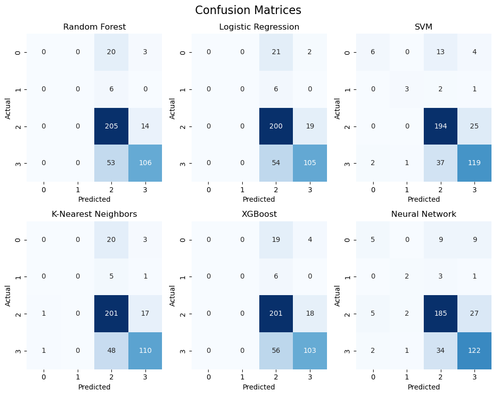

```python
classifier_names = [
    'Random Forest', 'Logistic Regression', 'SVM',
    'K-Nearest Neighbors', 'XGBoost', 'Neural Network'
]

fig, axes = plt.subplots(2, 3, figsize=(10, 8))
fig.suptitle('Confusion Matrices', fontsize=16)

axes = axes.ravel()


for i, (cm, name) in enumerate(zip(
    [cm_rf, cm_lr, cm_svc, cm_knn, cm_xgb, cm_nn],
    classifier_names
)):
    sns.heatmap(cm, annot=True, fmt='d', cmap='Blues', ax=axes[i], cbar=False)
    axes[i].set_title(name)
    axes[i].set_xlabel('Predicted')
    axes[i].set_ylabel('Actual')

plt.tight_layout()
plt.show()
```

In this second case, the top F1 scores are lower than those achieved by the previously best-performing SVM model. As before, the best overall performance is obtained when using the dataset that includes only the subset of target genes as features, employing SVM with parameters {'C': 10, 'gamma': 0.1, 'kernel': 'rbf'}.  
The overall performance of this model is:  
Accuracy: 0.8010 | Precision: 0.7998 | Recall: 0.8010 | F1 Score: 0.7915